# Collecting and Classifying Legislative Bills

Today's post pertains to a passion project of which I am part way through completing. The gist of the project is to create a social networking application which allows peers to delegate proxy votes on specific bills or all bills related to a specific policy area. This is more or less an implementation of a derivative of direct democracy called delegative, or liquid, democracy that attempts to mitigate voter apathy and ignorance by encouraging votes to propagate to individuals with knowledge about the given issue.

This is not a new concept at all. In fact, there are several instances of direct democracy techniques being employed. For example, Demoex is an experimental political party from Stockholm, Sweden that allows citizens to vote on local policy issues; Demoex party representitives vote in accordance with the majority decision reached through the application. This party was absorbed by a minor national political party, Direktdemokraterna, in 2014. Switzerland has long since been using directly democratic methods for civic engagement. The [Pirate Party](https://en.wikipedia.org/wiki/Pirate_Party) is another example of an existing institution which idealizes directy democracy.

There are at least a couple of problems with porting these ideologies to the United States. First, the United States, is a very large nation with many pockets of distinctly different cultures. Producing an application which fairly addresses the concerns of everyone is a challenge of scalability and flexibility. Secondly, the disengagement of citizenry will undoubtedly lead to many uncast votes causing a very skewed representation regarding policy positions. To address the concerns of scalability and flexibility, the application I'm working on features an extensible web scraping module that specifies an API that open source communities must adhere to when developing legislation collection routines for their locality. I've already implemented such routines for the city and county of San Francisco, the state of California, and at the federal level as well. To address the issue of citizen apathy and ignorance, I've constructed a pipeline that classifies collected legislation as belonging to one of 16 policy areas.

Once classified, a cosine similarity search procedure is performed to recommend legislation to users. This is made possible by updating users' policy area interest vectors which contain features matching the 16 policy areas. Every user action pertaining to a piece of legislation has a weighted effect when updating said vector. For example, a user clicking on a bill pertaining to education will boost the feature of the policy area interest vector for this user that captures their interest in education bills. Saving the bill for later or voting on it will have an even larger effect of the same kind. Contrarily, repeatedly delegating votes on foreign policy will deemphasize that feature. For all policy areas falling below some L2-norm threshold for a given user, the cosine similarity search procedure mentioned above identifies peers of that user who *are* interested in that policy area and recommends them as delegates for all bills belonging to that policy area.

To summarize, the primary goals of this application are to:

- produce a curated list of legislative content that, with high probability, will be of interest to the user
- recommend all the remaining legislative content to a peer who, with high probability, will be active regarding these bills
- increase civic engagement at all levels of governement -- especially local politics
- deemphasize identity politics and obsolesce politicians

## What this post covers

We will be going over the tools and techniques used to collect federal legislation and detail the process of producing a text classifier using scikit-learn's support vector machine linear classifier. I've opted to only discuss the collection federal legislation as this will be pertinent to a larger audience. In addition, the source for federal legislation is, by far, the most complete and simple to use; contrary to this would be city of San Francisco's documentation of introduced legislation which is so inconvientely published as a PDF upload to their website...if you're interested in seeing how I used Slate, the pdf-to-text Python library, to create a bill collection utility for SF, please take a look at [this module](https://github.com/a-rich/Liquidemocracy/blob/master/project/server/bill_collection/scrapers/cities/san_francisco/scraper.py).

## Congress.gov

[figure not shown]

```python
from IPython.display import Image
Image('congress.png', width=775)
```

Looking at the image below, we see that congress.gov maintains a large collection of bills dating back to 1973 with a multitude of filter options including policy area. This will be very handy when collecting training data for our classifier.

[figure not shown]

```python
Image('congress_leg.png', width=775)
```

By clicking through a few of these policy areas and observing the pattern of the URLs, we can deduce a scheme which will allows us to iterate through a list of desired policy area strings and use string substitution to create a complete link to visit in an automated fashion.

## Collecting bills for each policy area of interest

Below is a simplified version of the script used in my project to collect training data for the classifier. Instead of collecting 3000 bills for 16 different policy areas, this collects only 25 bills across 8 policy areas.

```python
import os
import json
import requests
from bs4 import BeautifulSoup

subjects = [
        'Taxation',
        'Health',
        'Crime and Law Enforcement',
        'Education',
        'Energy',
        'Labor and Employment',
        'Environmental Protection',
        'Science, Technology, Communications',
        ]

web_page = "https://www.congress.gov/search?q=%7B%22source%22%3A%22legislation%22%2C%22subject%22%3A%22{}%22%7D"

# Iterate all the policy areas of interest
for subject in subjects:
    print('Collection bills on {}'.format(subject))
    bill_texts = []
    root = 'https://www.congress.gov'
    link = web_page.format('+'.join(subject.split(' ')))

    # We must specify a user-agent in the request headers, otherwise congress.gov will disallow our scraper access
    page = requests.get(link, headers={'User-agent': 'bill collection'})

    soup = BeautifulSoup(page.text, 'html.parser')

    # These are the individual bill items on the page
    bill_divs = soup.find_all('li', {'class': 'expanded'})

    # Collect all the links on the page that lead us to the actual bill's page which includes the text
    # we want to scrape for training our classifier
    links = [b.find('a')['href'] for b in bill_divs]

    # Traverse the links to the individual bill pages; we're going to impose a 25 bill limit for the sake of time
    limit = 25
    for link in links[:limit]:
        page = requests.get(link, headers={'User-agent': 'bill collection'})
        soup = BeautifulSoup(page.text, 'html.parser')
        text = [a for a in soup.find('ul', {'class': 'tabs_links'}).find_all('a')
                if 'text' in a['href']][0]

        # Not all bills have text info...we want to skip these bills
        text_found = text.find('span', {'class': 'counter'}).get_text()

        if text_found:
            text_link = text['href']
            page = requests.get(root + text_link, headers={'User-agent': 'bill collection'})
            soup = BeautifulSoup(page.text, 'html.parser')
            text_container = soup.find('div', {'class': 'generated-html-container'})

            # Grrrr, non-uniformity in CSS naming
            if not text_container:
                text_container = soup.find('pre', {'id': 'billTextContainer'})

            text = ' '.join(text_container.get_text().split())
            bill_texts.append(text)

    # Write to a JSON file where keys are policy areas and values are lists of bills for those policy areas
    if os.path.exists('data.json'):
        data = json.load(open('data.json', 'r'))
    else:
        data = {}

    if subject in data:
        data[subject] += bill_texts
    else:
        data[subject] = bill_texts

    json.dump(data, open('data.json', 'w'))
```

```
Collection bills on Taxation
Collection bills on Health
Collection bills on Crime and Law Enforcement
Collection bills on Education
Collection bills on Energy
Collection bills on Labor and Employment
Collection bills on Environmental Protection
Collection bills on Science, Technology, Communications
```

## Processing data

Now we create numerical class labels for each data instance and clean the text using regular expressions. Prior to cleaning the full-scale dataset, I had a vocabulary of nearly 100,000 words. Several thousand of these "words" were actually just useless numbers. Many contained or were entirely underscores, punctuation characters, or other non-words like "aaaaaaiii" -- just wierd stuff that must be rid of.

```python
import re
import numpy as np

data = json.load(open('data.json', 'r'))

# Produce numerical value labels for each policy area
classes = {k: i for i,k in enumerate(data.keys())}

# Attach labels to each data instance
data = [(doc, classes[cls]) for cls, vals in data.items() for doc in vals]

docs = [d[0] for d in data]
labels = [d[1] for d in data]

# Iterate docs and clean them using regular expressions
for i, doc in enumerate(list(docs)):
    new_doc = []
    for word in re.split(r'\s+', doc):    # Split on one or more space characters
        # Use only words that don't have 3 or more repeating characters
        # and don't have underscores, digits, or non-word characters
        if not re.search(r'(.)\1{2,}|[_\d\W]+', word):
            new_doc.append(word)
    docs[i] = ' '.join(new_doc)
```

## More preprocessing

At this time, you may want to apply stemming and lemmatization to reduce the vocabulary of your dataset. Stemming finds the root of a word, i.e. "training" stems to "train". Lemmatization normalizes morphological differences in words with the same meaning, i.e. "is" and "are" are lemmatized to "be".

I found that, even for my full-scale training procedure with a regex cleaned vocabulary of approximately 60,000 words, stemming and lemmatization actually hurt by model's performance reducing it from 94% precision and recall to 93%. These processes *did*, however, successfully reduce the vocabulary to approximately 39,000 words.

If you decide to use stemming or lemmatization, there are several options to choose from in the Python ecosystem. The Natural Language Toolkit (NLTK) is an easy to use and fully-featured favorite. SpaCy is a newer and faster natural langauge processing package you may want to consider for production systems.

## Vectorize documents to create a document-term matrix

In order to proceed with classification, we must convert our character-based representation of the documents into a numerical form. To do this, we'll use scikit-learn, an exteremely useful and popular machine learning library. Scikit-learn's feature_extraction.text package contains a number of vectorization classes that we can use to create document-term matrices.

If we have `N` documents in our dataset and, across all these document, we have a total vocabulary of `M` unique words, the document-term matrix will be a `NxM` matrix with each document occupying a row and each term in the vocabularly occupying a column.

The simplest to explain vectorizer is `CountVectorizer` which will simply store a count for the number of times each word appears in each document. While simple, this may not be the best representation to use. To see why, think about the word "the"; it is the most common 3-gram sequence of characters in the English language. A given document will probably have the largest count for "the" relative to all other words in the vocabulary. The numerical representation of our document will have a really high weight for "the" and two documents that both have "the" appearing frequently in them will be gauged as quite similar -- but this isn't necessarily true because pretty much every document we'll ever collect will have "the" appearing in it many times. For this reason, we might prefer using the `TfidfVectorizer` or term frequency-inverse document frequency representation. The intuition behind tf-idf is that we want to reduce the weight of terms that appear in many of the documents even if they appear many times in a given document. To do this, we compute $\text{tf(term, document)} \times \text{idf(term, documents)}$ where $\text{tf(term, document)}$ is the number of times the given term appears in the given document and $\text{idf(term, documents)} = log\frac{\text{number of documents}}{\text{number of documents containing the given term}}$.

As you might imagine, most of the words in the vocabularly do **not** appear in a given document, so there will be many zero value counts in a document's term vector. For this reason, we call the resulting document-term matrix a *sparse* matrix. Representing sparse matrices using scikit-learn requires the package scipy which may or may not already be installed as a prerequisite of scikit-learn. Sparse matrices are frequently stored in compressed sparse row (CSR) format: instead of storing an explicit value for *every* index in the vocabulary, we store `(index, value)` pairs for only the non-zero values in the matrix. So long as there are more zero values than non-zero values in the document-term matrix, CSR format saves us space and time.

```python
from sklearn.feature_extraction.text import TfidfVectorizer

vec = TfidfVectorizer(strip_accents='unicode', stop_words='english')
dtm = vec.fit_transform(docs)
print(dtm.shape)
```

```
(200, 7243)
```

We can see by the shape of the resulting document-term matrix that we have 200 documents (25 bills for each of the 8 classes) and 7,243 terms in the vocabulary.

## Training and evaluation our bill classifier

Now we'll use some of scikit-learns utilities to train and evaluate a support vector machine linear classifier. A support vector machine applies a kernel function to the input data in order to project it into a higher dimension space. The reason why this is desirable is because our data is non-linear and our SVM produces a linear decision boundary between classes; the projection of our input data into a higher dimensional space, when done in a particular way, permits the distinct classes to become linearly sparable. How can we produce a linear decision boundary between 8 classes? In short, our model uses a one-versus-all technique, e.g. is the bill education related or not?

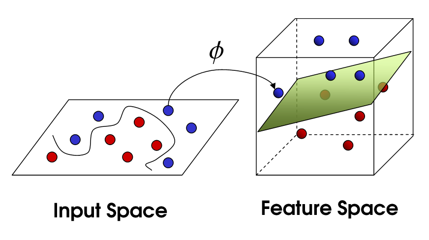

```python
# Photo taken from https://stackoverflow.com/questions/9480605/what-is-the-relation-between-the-number-of-support-vectors-and-training-data-and
Image('svm.png', width=775)
```

```python
from sklearn.model_selection import train_test_split
from sklearn.metrics import classification_report
from sklearn.svm import SVC, LinearSVC

# Create a 70/30 train/test split of the documents and their corresponding labels
X_train, X_test, y_train, y_test = train_test_split(dtm, labels, test_size=0.33, random_state=42)

clf = LinearSVC(loss='hinge')
clf.fit(X_train, y_train)
predictions = clf.predict(X_test)
report = classification_report(y_test, predictions)
print(report)
```

```
             precision    recall  f1-score   support
      0       1.00      0.88      0.93         8
      1       0.67      0.67      0.67         6
      2       0.75      0.67      0.71         9
      3       1.00      0.67      0.80        12
      4       0.78      1.00      0.88         7
      5       1.00      0.89      0.94         9
      6       0.75      0.90      0.82        10
      7       0.38      0.60      0.46         5



avg / total       0.83      0.79      0.80        66
```

An F1 score of 0.80 is not too bad, considering we had so few examples to train on. If want to get more impressive scores, we'll definitely need more samples. The classifier used in my project was trained on 48,000 samples (16 classes -- 3,000 samples for each class) and achieved a precision/recall/F1 of 94% of which I'm pretty satisifed with.